# Dimensionality Reduction

Joan Mwangi

7/16/2021

# Problem Definition

Reducing the dataset to low dimensional dataset using T-Distributed Stochastic Neighbor Embedding and draw insights from the analysis.

# Data Sourcing

```r
#previewing the first 6 rows
sales <- read.csv("C:/Users/jojos/Downloads/Supermarket_Dataset_1 - Sales Data (1).csv")
head(sales)
```

```
##    Invoice.ID Branch Customer.type Gender           Product.line Unit.price
## 1 750-67-8428      A        Member Female      Health and beauty      74.69
## 2 226-31-3081      C        Normal Female Electronic accessories      15.28
## 3 631-41-3108      A        Normal   Male     Home and lifestyle      46.33
## 4 123-19-1176      A        Member   Male      Health and beauty      58.22
## 5 373-73-7910      A        Normal   Male      Sports and travel      86.31
## 6 699-14-3026      C        Normal   Male Electronic accessories      85.39
##   Quantity     Tax      Date  Time     Payment   cogs gross.margin.percentage
## 1        7 26.1415  1/5/2019 13:08     Ewallet 522.83                4.761905
## 2        5  3.8200  3/8/2019 10:29        Cash  76.40                4.761905
## 3        7 16.2155  3/3/2019 13:23 Credit card 324.31                4.761905
## 4        8 23.2880 1/27/2019 20:33     Ewallet 465.76                4.761905
## 5        7 30.2085  2/8/2019 10:37     Ewallet 604.17                4.761905
## 6        7 29.8865 3/25/2019 18:30     Ewallet 597.73                4.761905
##   gross.income Rating    Total
## 1      26.1415    9.1 548.9715
## 2       3.8200    9.6  80.2200
## 3      16.2155    7.4 340.5255
## 4      23.2880    8.4 489.0480
## 5      30.2085    5.3 634.3785
## 6      29.8865    4.1 627.6165
```

# Check the Data

```r
#checking the structure of the dataset
sapply(sales,class)
```

```
##              Invoice.ID                  Branch           Customer.type
##             "character"             "character"             "character"
##                  Gender            Product.line              Unit.price
##             "character"             "character"               "numeric"
##                Quantity                     Tax                    Date
##               "integer"               "numeric"             "character"
##                    Time                 Payment                    cogs
##             "character"             "character"               "numeric"
## gross.margin.percentage            gross.income                  Rating
##               "numeric"               "numeric"               "numeric"
##                   Total
##               "numeric"
```

```r
class(sales)
```

```
## [1] "data.frame"
```

```r
dim(sales)
```

```
## [1] 1000   16
```

```r
colSums(is.na(sales))
```

```
##              Invoice.ID                  Branch           Customer.type
##                       0                       0                       0
##                  Gender            Product.line              Unit.price
##                       0                       0                       0
##                Quantity                     Tax                    Date
##                       0                       0                       0
##                    Time                 Payment                    cogs
##                       0                       0                       0
## gross.margin.percentage            gross.income                  Rating
##                       0                       0                       0
##                   Total
##                       0
```

```r
duplicates <- sales[duplicated(sales),]
duplicates
```

```
##  [1] Invoice.ID              Branch                  Customer.type
##  [4] Gender                  Product.line            Unit.price
##  [7] Quantity                Tax                     Date
## [10] Time                    Payment                 cogs
## [13] gross.margin.percentage gross.income            Rating
## [16] Total
## <0 rows> (or 0-length row.names)
```

There are no duplicates

```
## 3 columns ignored with more than 50 categories.
## Invoice.ID: 1000 categories
## Date: 89 categories
## Time: 506 categories
```

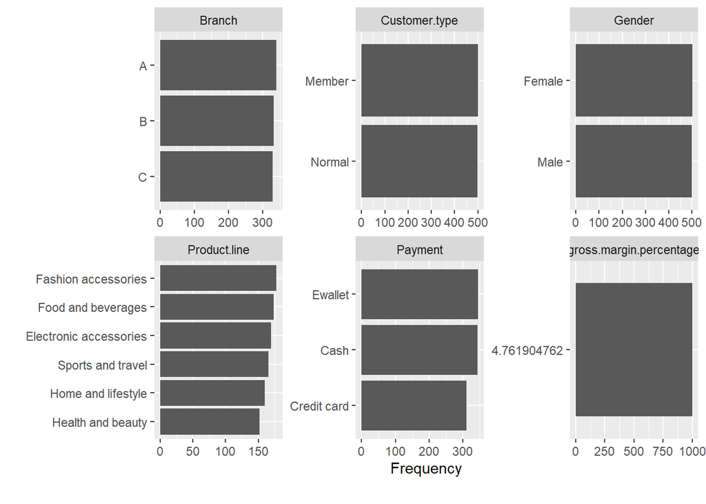

```r
library(DataExplorer)
plot_bar(sales)
```

Product line category: Fashion accessories has the highest count followed by food beverages

Payment : Ewallet and Cash had the most count

Branch A is slightly popular compared to branch B

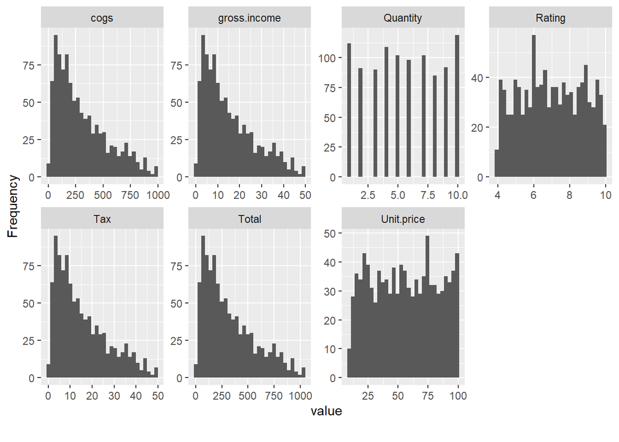

```r
plot_histogram(sales)
```

```r
library(psych)
```

```r
describe(sales)
```

```
##                         vars    n   mean     sd median trimmed    mad   min
## Invoice.ID*                1 1000 500.50 288.82 500.50  500.50 370.65  1.00
## Branch*                    2 1000   1.99   0.82   2.00    1.99   1.48  1.00
## Customer.type*             3 1000   1.50   0.50   1.00    1.50   0.00  1.00
## Gender*                    4 1000   1.50   0.50   1.00    1.50   0.00  1.00
## Product.line*              5 1000   3.45   1.72   3.00    3.44   1.48  1.00
## Unit.price                 6 1000  55.67  26.49  55.23   55.62  33.37 10.08
## Quantity                   7 1000   5.51   2.92   5.00    5.51   2.97  1.00
## Tax                        8 1000  15.38  11.71  12.09   14.00  11.13  0.51
## Date*                      9 1000  45.58  25.89  47.00   45.63  34.10  1.00
## Time*                     10 1000 252.18 147.07 249.00  252.49 190.51  1.00
## Payment*                  11 1000   2.00   0.83   2.00    2.00   1.48  1.00
## cogs                      12 1000 307.59 234.18 241.76  279.91 222.65 10.17
## gross.margin.percentage   13 1000   4.76   0.00   4.76    4.76   0.00  4.76
## gross.income              14 1000  15.38  11.71  12.09   14.00  11.13  0.51
## Rating                    15 1000   6.97   1.72   7.00    6.97   2.22  4.00
## Total                     16 1000 322.97 245.89 253.85  293.91 233.78 10.68
##                             max   range  skew kurtosis   se
## Invoice.ID*             1000.00  999.00  0.00    -1.20 9.13
## Branch*                    3.00    2.00  0.02    -1.51 0.03
## Customer.type*             2.00    1.00  0.00    -2.00 0.02
## Gender*                    2.00    1.00  0.00    -2.00 0.02
## Product.line*              6.00    5.00  0.06    -1.28 0.05
## Unit.price                99.96   89.88  0.01    -1.22 0.84
## Quantity                  10.00    9.00  0.01    -1.22 0.09
## Tax                       49.65   49.14  0.89    -0.09 0.37
## Date*                     89.00   88.00 -0.03    -1.23 0.82
## Time*                    506.00  505.00  0.00    -1.25 4.65
## Payment*                   3.00    2.00  0.00    -1.55 0.03
## cogs                     993.00  982.83  0.89    -0.09 7.41
## gross.margin.percentage    4.76    0.00   NaN      NaN 0.00
## gross.income              49.65   49.14  0.89    -0.09 0.37
## Rating                    10.00    6.00  0.01    -1.16 0.05
## Total                   1042.65 1031.97  0.89    -0.09 7.78
```

## Bivariate Analysis

```r
correlation <- cor(sales[,c(6:8,12,13,14,15,16)])
```

[figure not shown]

[output not shown]

[output not shown]

```r
library(corrplot)
corrplot(correlation, use= "complete.obs")
```

```r
#plotting
colors <- rainbow(length(unique(lbl)))#images for colors
names(colors) = unique(lbl)
```

```r
library(Rtsne)
tsne <- Rtsne(sales,dim=2,perplexity=30,verbose=TRUE,max_iter=500)
```

```
## Performing PCA
## Read the 1000 x 50 data matrix successfully!
## OpenMP is working. 1 threads.
## Using no_dims = 2, perplexity = 30.000000, and theta = 0.500000
## Computing input similarities...
## Building tree...
## Done in 0.22 seconds (sparsity = 0.101262)!
## Learning embedding...
## Iteration 50: error is 59.941944 (50 iterations in 0.14 seconds)
## Iteration 100: error is 51.804234 (50 iterations in 0.13 seconds)
## Iteration 150: error is 50.660831 (50 iterations in 0.14 seconds)
## Iteration 200: error is 50.220384 (50 iterations in 0.15 seconds)
## Iteration 250: error is 49.977947 (50 iterations in 0.16 seconds)
## Iteration 300: error is 0.548723 (50 iterations in 0.15 seconds)
## Iteration 350: error is 0.390314 (50 iterations in 0.14 seconds)
## Iteration 400: error is 0.351880 (50 iterations in 0.14 seconds)
## Iteration 450: error is 0.335137 (50 iterations in 0.14 seconds)
## Iteration 500: error is 0.323912 (50 iterations in 0.14 seconds)
## Fitting performed in 1.42 seconds.
```

```r
#computing the execution time
exeTimeTsne <- system.time(Rtsne(sales[,-16],dims=2,perplexity=30,verbose=TRUE,max_iter=500))
```

```
## Performing PCA
## Read the 1000 x 50 data matrix successfully!
## OpenMP is working. 1 threads.
## Using no_dims = 2, perplexity = 30.000000, and theta = 0.500000
## Computing input similarities...
## Building tree...
## Done in 0.21 seconds (sparsity = 0.102660)!
## Learning embedding...
## Iteration 50: error is 60.668691 (50 iterations in 0.14 seconds)
## Iteration 100: error is 53.005004 (50 iterations in 0.13 seconds)
## Iteration 150: error is 51.563210 (50 iterations in 0.13 seconds)
## Iteration 200: error is 50.969771 (50 iterations in 0.14 seconds)
## Iteration 250: error is 50.666204 (50 iterations in 0.14 seconds)
## Iteration 300: error is 0.602845 (50 iterations in 0.13 seconds)
## Iteration 350: error is 0.424101 (50 iterations in 0.14 seconds)
## Iteration 400: error is 0.376388 (50 iterations in 0.14 seconds)
## Iteration 450: error is 0.360184 (50 iterations in 0.14 seconds)
## Iteration 500: error is 0.351389 (50 iterations in 0.13 seconds)
## Fitting performed in 1.37 seconds.
```

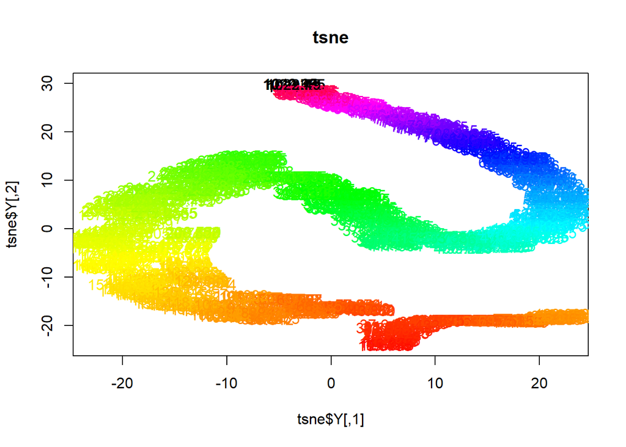

```r
#plotting the graph and examining the graph
plot(tsne$Y,t="n",main="tsne")
text(tsne$Y,labels=sales$Total,col=colors[sales$Total])
```

## Comparing with PCA

```r
#selecting numerical columns
sales_num <- sales[sapply(sales,is.numeric)]
head(sales_num)
```

```
##   Unit.price Quantity     Tax   cogs gross.margin.percentage gross.income
## 1      74.69        7 26.1415 522.83                4.761905      26.1415
## 2      15.28        5  3.8200  76.40                4.761905       3.8200
## 3      46.33        7 16.2155 324.31                4.761905      16.2155
## 4      58.22        8 23.2880 465.76                4.761905      23.2880
## 5      86.31        7 30.2085 604.17                4.761905      30.2085
## 6      85.39        7 29.8865 597.73                4.761905      29.8865
##   Rating    Total
## 1    9.1 548.9715
## 2    9.6  80.2200
## 3    7.4 340.5255
## 4    8.4 489.0480
## 5    5.3 634.3785
## 6    4.1 627.6165
```

```r
#creating a function for normality
norm <- function(x){return((x-min(x))/max(x)-min(x))
}
#normalizing the whole dataset
sales_num <- norm(sales_num[,-8])
sales.pca <- prcomp(sales_num)
summary(sales.pca)
```

```
## Importance of components:
##                           PC1     PC2      PC3      PC4       PC5       PC6
## Standard deviation     0.2370 0.02065 0.001731 0.001255 4.923e-17 2.787e-18
## Proportion of Variance 0.9924 0.00753 0.000050 0.000030 0.000e+00 0.000e+00
## Cumulative Proportion  0.9924 0.99992 0.999970 1.000000 1.000e+00 1.000e+00
##                              PC7
## Standard deviation     5.289e-34
## Proportion of Variance 0.000e+00
## Cumulative Proportion  1.000e+00
```

From the summary, the PC1 takes 99.24% of the total variation

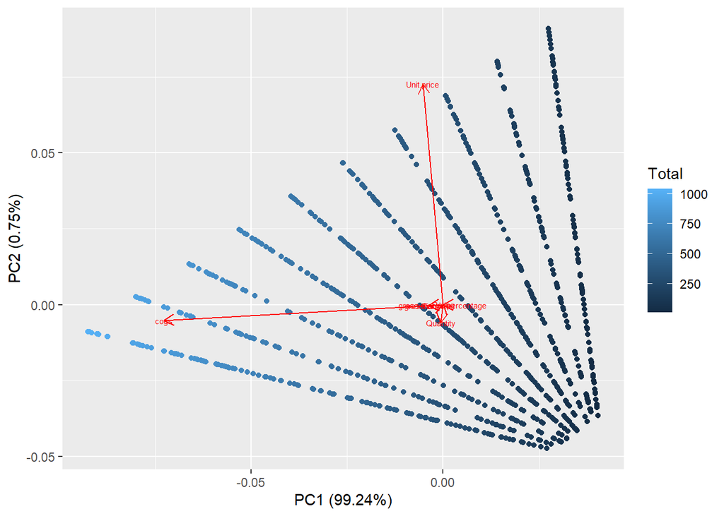

```r
#loading ggbiplot library for visualization
#library(ggbiplot)
library(ggplot2)
library(scales)
library(plyr)
library(grid)
library(devtools)
library(ggbiplot)
#install.packages("ggfortify")
library(ggfortify)
autoplot(sales.pca, data = sales, colour = 'Total', loadings = TRUE,loadings.label=TRUE,loadings.label.size=2)
```

TSNE performs better in clustering compared to pca, as pca identified only one principal components while tsne made a slight distinguish in their clusters.